# Anotacion de datos de Expresion diferencial con Clusterprofiler

Anotacion de datos de Expresion diferencial con Clusterprofiler Dra. Linda Aimara Kempis Calanis 2025-11-25

## Librerías necesarias:

- **tidyverse**: Manipulación de dataframes.
- **clusterProfiler**: Conversión de IDs y análisis de enriquecimiento.
- **org.Hs.eg.db**: Base de datos anotada de genes Humanos.

```r
####Librerias necesarias####
library(clusterProfiler)
library(org.Hs.eg.db)
```

```r
library(ggplot2)
```

## 2. Cargar datos y ajustar parámetros

La tabla de expresión diferencial generada por *edgeR* contiene:

- LogFC: Cambios en la expresión (log2 Fold Change)
- FDR: Tasa de Falsos Descubrimientos (controla error tipo I)
- gene: Nombre del gen en SYMBOL

Los umbrales utilizados:

- **FDR ≤ 0.05**: Controla la proporción esperada de falsos positivos.
- **|logFC| ≥ 1**: Significa que el cambio es al menos 2 veces (log2(2)=1).

```r
# Debemos elegir la direccion de los archivos
# Leer las tablas necesarias para las comparaciones neonatos vs adultos
res_df1 <-read.table("Neo_vs_Adultos_DiffExp_edgeR.txt")
dim(res_df1)
```

```
## [1] 756   5
```

```r
padj.cutoff <-0.05
lfc.cutoff<- 1
```

## 3. Filtrar genes diferencialmente expresados

Aquí seleccionamos genes sobreexpresados en neonatos y en adultos:

```r
# Seleccionar el entrezgeid de los genes up and down de las tablas

GDE_Neo <- res_df1 %>% filter(FDR<= padj.cutoff & logFC <= -lfc.cutoff)
dim(GDE_Neo)
```

```
## [1] 421   5
```

```r
View(GDE_Neo)
GDE_Adul <- res_df1 %>% filter(FDR<= padj.cutoff & logFC >= lfc.cutoff)
dim(GDE_Adul)
```

```
## [1] 335   5
```

```r
gene_adul <- GDE_Adul$gene
length(gene_adul)
```

```
## [1] 335
```

```r
gene_neo  <- GDE_Neo$gene
View(gene_neo)
```

# 4. Extraer los nombres de los genes (SYMBOL)

Aquí tomamos solo la columna de nombres de genes (SYMBOL), necesaria para convertirlos posteriormente a ENTREZID, ya que bases como KEGG y GO trabajan con esos identificadores.

```r
## convertir los genes a entrezgenid
genes_neo_entrez = bitr(gene_neo, fromType = "SYMBOL", toType = "ENTREZID", OrgDb ="org.Hs.eg.db" )
View(genes_neo_entrez)
genes_adu_entrez = bitr(gene_adul, fromType = "SYMBOL", toType = "ENTREZID", OrgDb ="org.Hs.eg.db" )
View(genes_adu_entrez)

col_genes_neo_entrez <- genes_neo_entrez$ENTREZID
col_genes_adu_entrez <- genes_adu_entrez$ENTREZID
```

🧬 Análisis de enriquecimiento funcional (GO)

En esta sección realizamos:

- Enriquecimiento GO (Biological Processes) para genes diferencialmente expresados en neonatos
- Comparación de GO entre neonatos y adultos
- Visualización con dotplots
- Exportación de resultados

## 🟦 Enriquecimiento GO para genes de neonatos

La función enrichGO() identifica procesos biológicos (BP) sobrerrepresentados en un conjunto de genes. Se usa:

- gene: vector de ENTREZID
- OrgDb: base de datos anotada de humano
- ont = “BP”: categoría Biological Processes
- pvalueCutoff: umbral de significancia
- qvalueCutoff: controla FDR

```r
kk <- enrichGO(
  gene          = col_genes_neo_entrez,  # Lista de ENTREZID de genes expresados en neonatos
  OrgDb         = org.Hs.eg.db,          # Base de datos anotada (Homo sapiens)
  ont           = "BP",                  # Ontología: Biological Process
  pvalueCutoff  = 0.05,                  # Valor p máximo permitido
  qvalueCutoff  = 0.1                    # FDR máximo permitido
)
```

## 🟩 Visualización del enriquecimiento GO (Dotplot)

**dotplot()** muestra los términos GO más significativos. Cada punto representa un proceso biológico enriquecido.

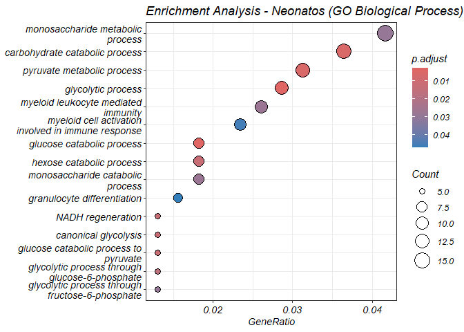

```r
via <- dotplot(kk, showCategory = 20, font.size = 10.5) +
  ggtitle("Enrichment Analysis - Neonatos (GO Biological Process)")

via
```

## 🟦 Crear una lista de genes por grupo

Esta lista es necesaria para comparar enriquecimientos entre neonatos y adultos.

```r
lista_NeovsAdu <- list(
  "Neonatos" = col_genes_neo_entrez,  # ENTREZID de neonatos
  "Adultos"  = col_genes_adu_entrez   # ENTREZID de adultos
)
```

🟧 Comparación de enriquecimiento GO entre grupos (compareCluster)

```r
clusters_GO <- compareCluster(
  geneCluster   = lista_NeovsAdu,     # Lista con Neonatos vs Adultos
  fun           = enrichGO,           # Tipo de análisis: GO
  OrgDb         = "org.Hs.eg.db",
  ont           = "BP",
  pvalueCutoff  = 0.05,
  qvalueCutoff  = 0.1
)

View(clusters_GO)
class(clusters_GO)
```

```
## [1] "compareClusterResult"
## attr(,"package")
## [1] "DOSE"
```

## 📁 Guardar tabla de resultados GO

```r
write.table(
  clusters_GO,
  file = "clusterprofiler_GO.txt",
  sep = "\t",
  col.names = TRUE
)
```

## Dotplot de procesos biológicos GO (comparación Neonatos vs Adultos)

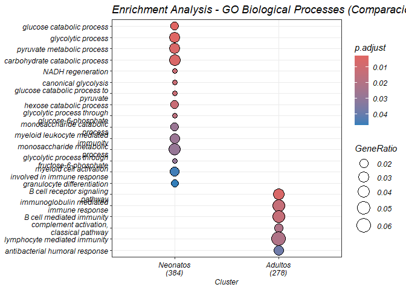

```r
vias_GO <- dotplot(
  clusters_GO,
  showCategory = 20,
  font.size = 9
) + ggtitle("Enrichment Analysis - GO Biological Processes (Comparación)")

vias_GO
```